# Risk Factor Analysis

## Outcome Variable

**Outcome Variable:** sstunted

## Predictor Variables

**Intervention Variable:** impfloor

**Adjustment Set:**

- arm
- sex
- W_mage
- meducyrs
- feducyrs
- hhwealth_quart
- hfoodsec
- W_mhtcm
- W_mwtkg
- W_mbmi
- W_nrooms
- W_nchldlt5
- W_parity
- impsan
- safeh20
- delta_W_mage
- delta_meducyrs
- delta_feducyrs
- delta_hhwealth_quart
- delta_hfoodsec
- delta_W_mhtcm
- delta_W_mwtkg
- delta_W_mbmi
- delta_W_nrooms
- delta_W_nchldlt5
- delta_W_parity
- delta_impsan
- delta_safeh20

## Stratifying Variables

The analysis was stratified on these variable(s):

- agecat
- studyid
- country

## Data Summary

| agecat | studyid | country | impfloor | sstunted | n_cell | n |
| --- | --- | --- | --- | --- | --- | --- |
| Birth | CMC-V-BCS-2002 | INDIA | 1 | 0 | 68 | 72 |
| Birth | CMC-V-BCS-2002 | INDIA | 1 | 1 | 4 | 72 |
| Birth | CMC-V-BCS-2002 | INDIA | 0 | 0 | 0 | 72 |
| Birth | CMC-V-BCS-2002 | INDIA | 0 | 1 | 0 | 72 |
| Birth | CONTENT | PERU | 1 | 0 | 2 | 2 |
| Birth | CONTENT | PERU | 1 | 1 | 0 | 2 |
| Birth | CONTENT | PERU | 0 | 0 | 0 | 2 |
| Birth | CONTENT | PERU | 0 | 1 | 0 | 2 |
| Birth | GMS-Nepal | NEPAL | 1 | 0 | 98 | 544 |
| Birth | GMS-Nepal | NEPAL | 1 | 1 | 2 | 544 |
| Birth | GMS-Nepal | NEPAL | 0 | 0 | 420 | 544 |
| Birth | GMS-Nepal | NEPAL | 0 | 1 | 24 | 544 |
| Birth | IRC | INDIA | 1 | 0 | 274 | 287 |
| Birth | IRC | INDIA | 1 | 1 | 13 | 287 |
| Birth | IRC | INDIA | 0 | 0 | 0 | 287 |
| Birth | IRC | INDIA | 0 | 1 | 0 | 287 |
| Birth | JiVitA-3 | BANGLADESH | 1 | 0 | 1307 | 22399 |
| Birth | JiVitA-3 | BANGLADESH | 1 | 1 | 87 | 22399 |
| Birth | JiVitA-3 | BANGLADESH | 0 | 0 | 18649 | 22399 |
| Birth | JiVitA-3 | BANGLADESH | 0 | 1 | 2356 | 22399 |
| Birth | JiVitA-4 | BANGLADESH | 1 | 0 | 289 | 2820 |
| Birth | JiVitA-4 | BANGLADESH | 1 | 1 | 18 | 2820 |
| Birth | JiVitA-4 | BANGLADESH | 0 | 0 | 2298 | 2820 |
| Birth | JiVitA-4 | BANGLADESH | 0 | 1 | 215 | 2820 |
| Birth | MAL-ED | BANGLADESH | 1 | 0 | 190 | 213 |
| Birth | MAL-ED | BANGLADESH | 1 | 1 | 6 | 213 |
| Birth | MAL-ED | BANGLADESH | 0 | 0 | 17 | 213 |
| Birth | MAL-ED | BANGLADESH | 0 | 1 | 0 | 213 |
| Birth | MAL-ED | BRAZIL | 1 | 0 | 55 | 60 |
| Birth | MAL-ED | BRAZIL | 1 | 1 | 3 | 60 |

[output cut: 162 more lines]

The following strata were considered:

- agecat: 24 months, studyid: CMC-V-BCS-2002, country: INDIA
- agecat: 24 months, studyid: CONTENT, country: PERU
- agecat: 24 months, studyid: GMS-Nepal, country: NEPAL
- agecat: 24 months, studyid: IRC, country: INDIA
- agecat: 24 months, studyid: JiVitA-3, country: BANGLADESH
- agecat: 24 months, studyid: JiVitA-4, country: BANGLADESH
- agecat: 24 months, studyid: MAL-ED, country: BANGLADESH
- agecat: 24 months, studyid: MAL-ED, country: BRAZIL
- agecat: 24 months, studyid: MAL-ED, country: INDIA
- agecat: 24 months, studyid: MAL-ED, country: NEPAL
- agecat: 24 months, studyid: MAL-ED, country: PERU
- agecat: 24 months, studyid: MAL-ED, country: SOUTH AFRICA
- agecat: 24 months, studyid: MAL-ED, country: TANZANIA, UNITED REPUBLIC OF
- agecat: 24 months, studyid: NIH-Birth, country: BANGLADESH
- agecat: 24 months, studyid: NIH-Crypto, country: BANGLADESH
- agecat: 24 months, studyid: PROVIDE, country: BANGLADESH
- agecat: 6 months, studyid: CMC-V-BCS-2002, country: INDIA
- agecat: 6 months, studyid: CONTENT, country: PERU
- agecat: 6 months, studyid: GMS-Nepal, country: NEPAL
- agecat: 6 months, studyid: IRC, country: INDIA
- agecat: 6 months, studyid: JiVitA-3, country: BANGLADESH
- agecat: 6 months, studyid: JiVitA-4, country: BANGLADESH
- agecat: 6 months, studyid: MAL-ED, country: BANGLADESH
- agecat: 6 months, studyid: MAL-ED, country: BRAZIL
- agecat: 6 months, studyid: MAL-ED, country: INDIA
- agecat: 6 months, studyid: MAL-ED, country: NEPAL
- agecat: 6 months, studyid: MAL-ED, country: PERU
- agecat: 6 months, studyid: MAL-ED, country: SOUTH AFRICA
- agecat: 6 months, studyid: MAL-ED, country: TANZANIA, UNITED REPUBLIC OF
- agecat: 6 months, studyid: NIH-Birth, country: BANGLADESH
- agecat: 6 months, studyid: NIH-Crypto, country: BANGLADESH
- agecat: 6 months, studyid: PROVIDE, country: BANGLADESH
- agecat: Birth, studyid: CMC-V-BCS-2002, country: INDIA
- agecat: Birth, studyid: CONTENT, country: PERU
- agecat: Birth, studyid: GMS-Nepal, country: NEPAL
- agecat: Birth, studyid: IRC, country: INDIA
- agecat: Birth, studyid: JiVitA-3, country: BANGLADESH
- agecat: Birth, studyid: JiVitA-4, country: BANGLADESH
- agecat: Birth, studyid: MAL-ED, country: BANGLADESH
- agecat: Birth, studyid: MAL-ED, country: BRAZIL
- agecat: Birth, studyid: MAL-ED, country: INDIA
- agecat: Birth, studyid: MAL-ED, country: NEPAL
- agecat: Birth, studyid: MAL-ED, country: PERU
- agecat: Birth, studyid: MAL-ED, country: SOUTH AFRICA
- agecat: Birth, studyid: MAL-ED, country: TANZANIA, UNITED REPUBLIC OF
- agecat: Birth, studyid: NIH-Birth, country: BANGLADESH
- agecat: Birth, studyid: NIH-Crypto, country: BANGLADESH
- agecat: Birth, studyid: PROVIDE, country: BANGLADESH

### Dropped Strata

Some strata were dropped due to rare outcomes:

- agecat: Birth, studyid: CMC-V-BCS-2002, country: INDIA
- agecat: Birth, studyid: CONTENT, country: PERU
- agecat: Birth, studyid: GMS-Nepal, country: NEPAL
- agecat: Birth, studyid: IRC, country: INDIA
- agecat: Birth, studyid: MAL-ED, country: BANGLADESH
- agecat: Birth, studyid: MAL-ED, country: BRAZIL
- agecat: Birth, studyid: MAL-ED, country: INDIA
- agecat: Birth, studyid: MAL-ED, country: NEPAL
- agecat: Birth, studyid: MAL-ED, country: PERU
- agecat: Birth, studyid: MAL-ED, country: SOUTH AFRICA
- agecat: Birth, studyid: MAL-ED, country: TANZANIA, UNITED REPUBLIC OF
- agecat: Birth, studyid: NIH-Birth, country: BANGLADESH
- agecat: Birth, studyid: NIH-Crypto, country: BANGLADESH
- agecat: Birth, studyid: PROVIDE, country: BANGLADESH
- agecat: 6 months, studyid: CMC-V-BCS-2002, country: INDIA
- agecat: 6 months, studyid: CONTENT, country: PERU
- agecat: 6 months, studyid: GMS-Nepal, country: NEPAL
- agecat: 6 months, studyid: IRC, country: INDIA
- agecat: 6 months, studyid: MAL-ED, country: BANGLADESH
- agecat: 6 months, studyid: MAL-ED, country: BRAZIL
- agecat: 6 months, studyid: MAL-ED, country: INDIA
- agecat: 6 months, studyid: MAL-ED, country: NEPAL
- agecat: 6 months, studyid: MAL-ED, country: PERU
- agecat: 6 months, studyid: MAL-ED, country: SOUTH AFRICA
- agecat: 6 months, studyid: MAL-ED, country: TANZANIA, UNITED REPUBLIC OF
- agecat: 6 months, studyid: NIH-Birth, country: BANGLADESH
- agecat: 24 months, studyid: CMC-V-BCS-2002, country: INDIA
- agecat: 24 months, studyid: CONTENT, country: PERU
- agecat: 24 months, studyid: GMS-Nepal, country: NEPAL
- agecat: 24 months, studyid: IRC, country: INDIA
- agecat: 24 months, studyid: MAL-ED, country: BANGLADESH
- agecat: 24 months, studyid: MAL-ED, country: BRAZIL
- agecat: 24 months, studyid: MAL-ED, country: INDIA
- agecat: 24 months, studyid: MAL-ED, country: NEPAL
- agecat: 24 months, studyid: MAL-ED, country: PERU
- agecat: 24 months, studyid: MAL-ED, country: SOUTH AFRICA
- agecat: 24 months, studyid: MAL-ED, country: TANZANIA, UNITED REPUBLIC OF

## Methods Detail

We’re interested in the causal parameters $E[Y_a]$ for all values of $a \in \mathcal{A}$. These parameters represent the mean outcome if, possibly contrary to fact, we intervened to set all units to have $A=a$. Under the randomization and positivity assumptions, these are identified by the statistical parameters $\psi_a=E_W[E_{Y|A,W}(Y|A=a,W)]$. In addition, we’re interested in the mean of $Y$, $E[Y]$ under no intervention (the observed mean). We will estimate these parameters by using SuperLearner to fit the relevant likelihood factors – $E_{Y|A,W}(Y|A=a,W)$ and $p(A=a|W)$, and then updating our likelihood fit using a joint TMLE.

For unadjusted analyses ($W=\{\}$), initial likelihoods were estimated using Lrnr_glm to estimate the simple $E(Y|A)$ and Lrnr_mean to estimate $p(A)$. For adjusted analyses, a small library containing Lrnr_glmnet, Lrnr_xgboost, and Lrnr_mean was used.

Having estimated these parameters, we will then use the delta method to estimate relative risks and attributable risks relative to a prespecified baseline level of $A$.

# Results Detail

## Results Plots

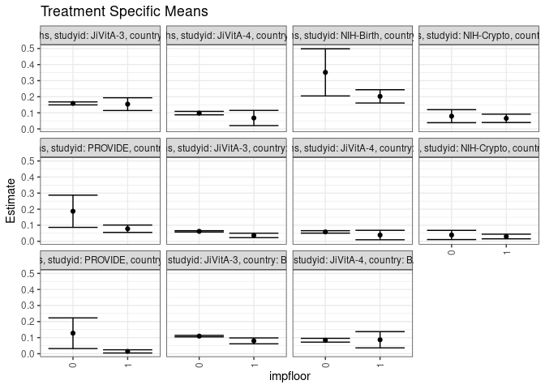

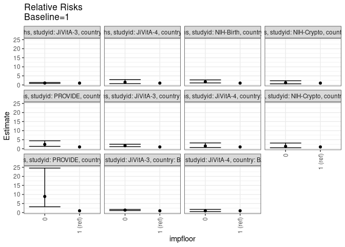

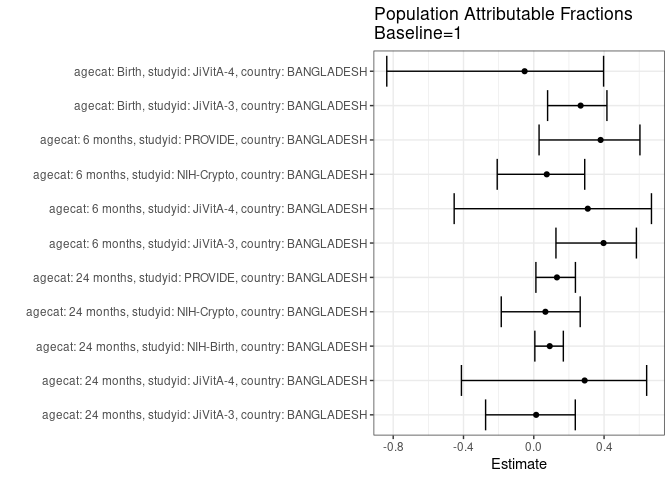

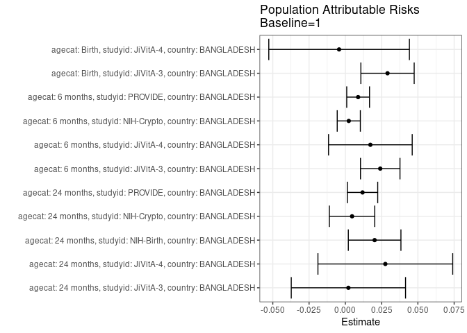

## Results Table

### Parameter: TSM

| agecat | studyid | country | intervention_level | baseline_level | estimate | ci_lower | ci_upper |
| --- | --- | --- | --- | --- | --- | --- | --- |
| Birth | JiVitA-3 | BANGLADESH | 1 | NA | 0.0799876 | 0.0616297 | 0.0983454 |
| Birth | JiVitA-3 | BANGLADESH | 0 | NA | 0.1095116 | 0.1047582 | 0.1142650 |
| Birth | JiVitA-4 | BANGLADESH | 1 | NA | 0.0869323 | 0.0363854 | 0.1374792 |
| Birth | JiVitA-4 | BANGLADESH | 0 | NA | 0.0839000 | 0.0721250 | 0.0956750 |
| 6 months | JiVitA-3 | BANGLADESH | 1 | NA | 0.0365176 | 0.0227181 | 0.0503171 |
| 6 months | JiVitA-3 | BANGLADESH | 0 | NA | 0.0618783 | 0.0578549 | 0.0659017 |
| 6 months | JiVitA-4 | BANGLADESH | 1 | NA | 0.0389196 | 0.0095487 | 0.0682904 |
| 6 months | JiVitA-4 | BANGLADESH | 0 | NA | 0.0583542 | 0.0508246 | 0.0658838 |
| 6 months | NIH-Crypto | BANGLADESH | 1 | NA | 0.0297952 | 0.0154049 | 0.0441854 |
| 6 months | NIH-Crypto | BANGLADESH | 0 | NA | 0.0393258 | 0.0107520 | 0.0678997 |
| 6 months | PROVIDE | BANGLADESH | 1 | NA | 0.0143627 | 0.0044736 | 0.0242517 |
| 6 months | PROVIDE | BANGLADESH | 0 | NA | 0.1276596 | 0.0321760 | 0.2231431 |
| 24 months | JiVitA-3 | BANGLADESH | 1 | NA | 0.1538953 | 0.1141639 | 0.1936268 |
| 24 months | JiVitA-3 | BANGLADESH | 0 | NA | 0.1585166 | 0.1493218 | 0.1677114 |
| 24 months | JiVitA-4 | BANGLADESH | 1 | NA | 0.0676724 | 0.0205069 | 0.1148379 |
| 24 months | JiVitA-4 | BANGLADESH | 0 | NA | 0.0981269 | 0.0874927 | 0.1087612 |
| 24 months | NIH-Birth | BANGLADESH | 1 | NA | 0.2022991 | 0.1610823 | 0.2435159 |
| 24 months | NIH-Birth | BANGLADESH | 0 | NA | 0.3517924 | 0.2051318 | 0.4984529 |
| 24 months | NIH-Crypto | BANGLADESH | 1 | NA | 0.0654049 | 0.0394431 | 0.0913667 |
| 24 months | NIH-Crypto | BANGLADESH | 0 | NA | 0.0789764 | 0.0384621 | 0.1194907 |
| 24 months | PROVIDE | BANGLADESH | 1 | NA | 0.0781097 | 0.0551964 | 0.1010229 |
| 24 months | PROVIDE | BANGLADESH | 0 | NA | 0.1869532 | 0.0866999 | 0.2872065 |

### Parameter: E(Y)

| agecat | studyid | country | intervention_level | baseline_level | estimate | ci_lower | ci_upper |
| --- | --- | --- | --- | --- | --- | --- | --- |
| Birth | JiVitA-3 | BANGLADESH | NA | NA | 0.1090674 | 0.1045072 | 0.1136275 |
| Birth | JiVitA-4 | BANGLADESH | NA | NA | 0.0826241 | 0.0709364 | 0.0943118 |
| 6 months | JiVitA-3 | BANGLADESH | NA | NA | 0.0605735 | 0.0567154 | 0.0644317 |
| 6 months | JiVitA-4 | BANGLADESH | NA | NA | 0.0561774 | 0.0493938 | 0.0629611 |
| 6 months | NIH-Crypto | BANGLADESH | NA | NA | 0.0321678 | 0.0192256 | 0.0451101 |
| 6 months | PROVIDE | BANGLADESH | NA | NA | 0.0231788 | 0.0111688 | 0.0351888 |
| 24 months | JiVitA-3 | BANGLADESH | NA | NA | 0.1559995 | 0.1472541 | 0.1647450 |
| 24 months | JiVitA-4 | BANGLADESH | NA | NA | 0.0952381 | 0.0856745 | 0.1048017 |
| 24 months | NIH-Birth | BANGLADESH | NA | NA | 0.2224824 | 0.1829871 | 0.2619778 |
| 24 months | NIH-Crypto | BANGLADESH | NA | NA | 0.0700389 | 0.0479542 | 0.0921236 |
| 24 months | PROVIDE | BANGLADESH | NA | NA | 0.0899654 | 0.0666186 | 0.1133122 |

### Parameter: RR

| agecat | studyid | country | intervention_level | baseline_level | estimate | ci_lower | ci_upper |
| --- | --- | --- | --- | --- | --- | --- | --- |
| Birth | JiVitA-3 | BANGLADESH | 1 | 1 | 1.0000000 | 1.0000000 | 1.000000 |
| Birth | JiVitA-3 | BANGLADESH | 0 | 1 | 1.3691078 | 1.0828837 | 1.730986 |
| Birth | JiVitA-4 | BANGLADESH | 1 | 1 | 1.0000000 | 1.0000000 | 1.000000 |
| Birth | JiVitA-4 | BANGLADESH | 0 | 1 | 0.9651188 | 0.5331941 | 1.746933 |
| 6 months | JiVitA-3 | BANGLADESH | 1 | 1 | 1.0000000 | 1.0000000 | 1.000000 |
| 6 months | JiVitA-3 | BANGLADESH | 0 | 1 | 1.6944778 | 1.1594021 | 2.476496 |
| 6 months | JiVitA-4 | BANGLADESH | 1 | 1 | 1.0000000 | 1.0000000 | 1.000000 |
| 6 months | JiVitA-4 | BANGLADESH | 0 | 1 | 1.4993532 | 0.6952684 | 3.233370 |
| 6 months | NIH-Crypto | BANGLADESH | 1 | 1 | 1.0000000 | 1.0000000 | 1.000000 |
| 6 months | NIH-Crypto | BANGLADESH | 0 | 1 | 1.3198736 | 0.5515999 | 3.158206 |
| 6 months | PROVIDE | BANGLADESH | 1 | 1 | 1.0000000 | 1.0000000 | 1.000000 |
| 6 months | PROVIDE | BANGLADESH | 0 | 1 | 8.8882979 | 3.2159417 | 24.565693 |
| 24 months | JiVitA-3 | BANGLADESH | 1 | 1 | 1.0000000 | 1.0000000 | 1.000000 |
| 24 months | JiVitA-3 | BANGLADESH | 0 | 1 | 1.0300286 | 0.7914634 | 1.340503 |
| 24 months | JiVitA-4 | BANGLADESH | 1 | 1 | 1.0000000 | 1.0000000 | 1.000000 |
| 24 months | JiVitA-4 | BANGLADESH | 0 | 1 | 1.4500286 | 0.7152726 | 2.939555 |
| 24 months | NIH-Birth | BANGLADESH | 1 | 1 | 1.0000000 | 1.0000000 | 1.000000 |
| 24 months | NIH-Birth | BANGLADESH | 0 | 1 | 1.7389714 | 1.0953407 | 2.760804 |
| 24 months | NIH-Crypto | BANGLADESH | 1 | 1 | 1.0000000 | 1.0000000 | 1.000000 |
| 24 months | NIH-Crypto | BANGLADESH | 0 | 1 | 1.2074994 | 0.6312994 | 2.309609 |
| 24 months | PROVIDE | BANGLADESH | 1 | 1 | 1.0000000 | 1.0000000 | 1.000000 |
| 24 months | PROVIDE | BANGLADESH | 0 | 1 | 2.3934706 | 1.3029435 | 4.396738 |

### Parameter: PAR

| agecat | studyid | country | intervention_level | baseline_level | estimate | ci_lower | ci_upper |
| --- | --- | --- | --- | --- | --- | --- | --- |
| Birth | JiVitA-3 | BANGLADESH | 1 | NA | 0.0290798 | 0.0107106 | 0.0474490 |
| Birth | JiVitA-4 | BANGLADESH | 1 | NA | -0.0043082 | -0.0527719 | 0.0441555 |
| 6 months | JiVitA-3 | BANGLADESH | 1 | NA | 0.0240559 | 0.0104462 | 0.0376657 |
| 6 months | JiVitA-4 | BANGLADESH | 1 | NA | 0.0172579 | -0.0115720 | 0.0460877 |
| 6 months | NIH-Crypto | BANGLADESH | 1 | NA | 0.0023727 | -0.0055977 | 0.0103431 |
| 6 months | PROVIDE | BANGLADESH | 1 | NA | 0.0088162 | 0.0009634 | 0.0166689 |
| 24 months | JiVitA-3 | BANGLADESH | 1 | NA | 0.0021042 | -0.0372836 | 0.0414921 |
| 24 months | JiVitA-4 | BANGLADESH | 1 | NA | 0.0275657 | -0.0188866 | 0.0740180 |
| 24 months | NIH-Birth | BANGLADESH | 1 | NA | 0.0201833 | 0.0020487 | 0.0383179 |
| 24 months | NIH-Crypto | BANGLADESH | 1 | NA | 0.0046340 | -0.0110050 | 0.0202730 |
| 24 months | PROVIDE | BANGLADESH | 1 | NA | 0.0118557 | 0.0013987 | 0.0223128 |

### Parameter: PAF

| agecat | studyid | country | intervention_level | baseline_level | estimate | ci_lower | ci_upper |
| --- | --- | --- | --- | --- | --- | --- | --- |
| Birth | JiVitA-3 | BANGLADESH | 1 | NA | 0.2666224 | 0.0786077 | 0.4162717 |
| Birth | JiVitA-4 | BANGLADESH | 1 | NA | -0.0521422 | -0.8366230 | 0.3972616 |
| 6 months | JiVitA-3 | BANGLADESH | 1 | NA | 0.3971358 | 0.1261823 | 0.5840720 |
| 6 months | JiVitA-4 | BANGLADESH | 1 | NA | 0.3072030 | -0.4530758 | 0.6696885 |
| 6 months | NIH-Crypto | BANGLADESH | 1 | NA | 0.0737592 | -0.2081364 | 0.2898798 |
| 6 months | PROVIDE | BANGLADESH | 1 | NA | 0.3803539 | 0.0300934 | 0.6041256 |
| 24 months | JiVitA-3 | BANGLADESH | 1 | NA | 0.0134887 | -0.2741831 | 0.2362129 |
| 24 months | JiVitA-4 | BANGLADESH | 1 | NA | 0.2894398 | -0.4117206 | 0.6423543 |
| 24 months | NIH-Birth | BANGLADESH | 1 | NA | 0.0907187 | 0.0060405 | 0.1681830 |
| 24 months | NIH-Crypto | BANGLADESH | 1 | NA | 0.0661630 | -0.1850847 | 0.2641441 |
| 24 months | PROVIDE | BANGLADESH | 1 | NA | 0.1317811 | 0.0120891 | 0.2369716 |